# Replication Report on Renshon (2014)

Sean Hughes

## Abstract

I replicate and expand upon the work in “Physiological Arousal and Political Beliefs” (Renshon (2014a)) using data and replication code from the Harvard Dataverse (Renshon (2014b)). In this paper Renshon, Lee, and Tingley explore the effects of incidental emotions on political beliefs. Specifically, by showing that heightened physiological reactivity, measured by SCL, mediated the relationship between anxiety and anti-immigration attitude, they are able to provide evidence that emotions incidental to the decision process can have important effects on our political beliefs.

I replicate and offer improved versions of 2 figures and 1 table from the article (located in the Appendix below). I also test the robustness of the results of the study using alternative modeling techniques.

## Extension Analysis

#### Overview

I examine the role of pretreatment features in the trial using linear modeling and newly creted dummy variables. I then use bayesian linear modeling tequniques to test the link between skin conductivity and responses to immigration questions.

### Discussions

The following three correlations or lack therof create an interesting situation: the link between treatment condition and SCL, the link between SCL and immigration questionare results, and the lack of a link between treatment and immigration questionare results. This link where X correlates with Y and Y with Z but X does not correlate with Z suggets that there may be other factors at play. The author suggests that " we cannot say for sure whether other discrete emotions (such as disgust or excitement) or even physical activity (such as running) which generate physiological arousal might not have similar effects(Renshon (2014a))“. This means that the author is saying that while they can, and do, effectively stimulate SCL using the video pretreatment, that there could be other factors that they do not understand that impact the levels. This conclusion means that one cannot say that a link has been drawn between incidental emotions and political opinions, only that skin conductivity increases when one selects more conservative viewpoints on immigration in this study.

## Extension 1: Basic Linear Model

Using the main results table (Appendix Table 1) the authors claim that skin conductance reactivity is a significant predictor of immigration preference. Note that the authors of the paper choose to filter out data from the “RELAX” condition, citing that the results remain unchanged if included. We will include the RELAX condition and combine the 3 treatments into a binary variable with the following values: 1 if treatment condition is Anxiety 0 if treatment condition is Neutral or Relax

#### Model 1

A linear model of the video treatment condition (Relax, Neutral, or Anxiety) versus Skin Conductance readings.

#### Model 2

A linear model of the video treatment condition versus postreatment Immigration questionare responses.

#### Model 3

A linear model of Skin Conductance versus postreatment Immigration questionare responses.

#### Model 4

A linear model of the video treatment condition versus Skin Conductance readings and a variety of covariates from the pretreatment survey. The “Conservative” dummy variable was created by selecting all answers to the Ideology section of the pretreatment questionare that leaned conservative (responses were ranked on a 1 - 7 scale with 1 being very liberal and 7 being very conservative). The “High Income” dummy variable was created by selecting all users who had an income of $80k annualy or greater. The “White” dummy variable was created by selecting all users who responded to the Race section of the pretreatment questionare and indicated that they identified as white.

#### Model 5

A linear model of the Skin Conductance versus postreatment Immigration questionare responses including a variety of covariates from the pretreatment survey.

**Table 1. Basic Linear Models**

[output not shown]

## Extension 2: Bayesian Model

We fit the data with a bayesian linear model using the SCL conductivity measurements as the only predictor. We see the posterior distribution which refers to the probability distribution of an unknown quantity when treated as a random variable.

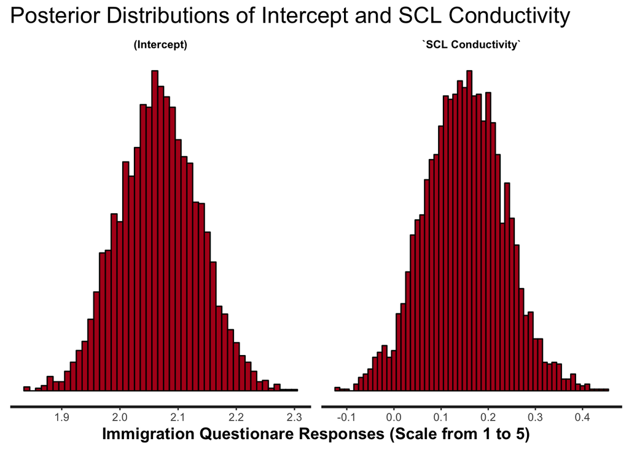

## Appendix

### Figure 2: Skin Conductivity Confidence Intervals

When calculating the mean points for the different treatments I receive different results than are demonstrated in the paper. However, these results still show the same trend as shown in the paper: that the anxiety video condition effectively causes the user to experience anxiety and that the relax condition causes the amount of anxiety to be reduced. These results assume that Skin Conductivity Reactivity is a reasonable gauge of anxiety as described in the paper.

[figure not shown]

### Table 1: Main Results

I was able to succesfully recreate all of table 1.

**Table 1. Main Results**

[output not shown]

### Table 1: Graphical Representation

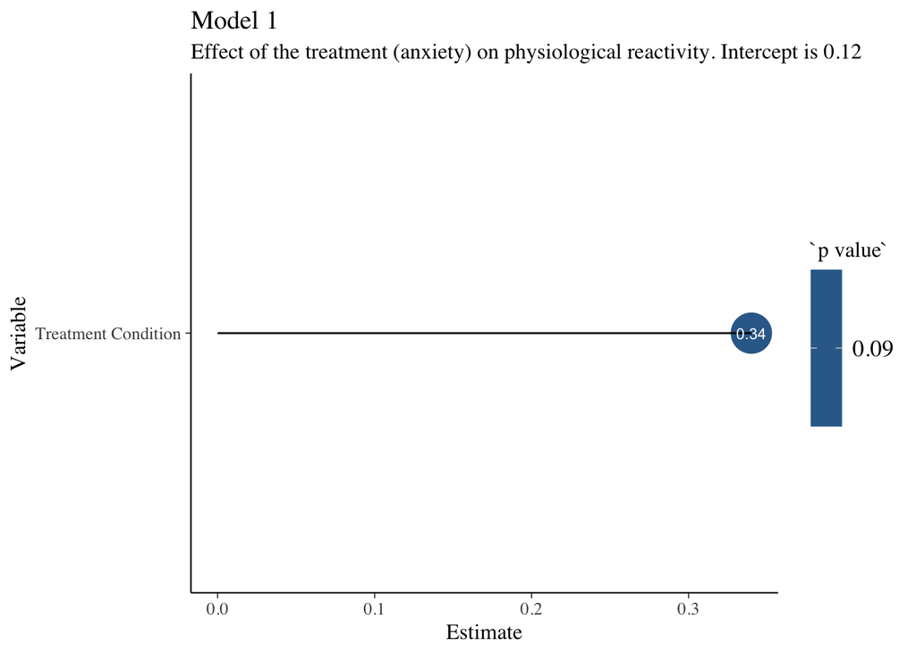

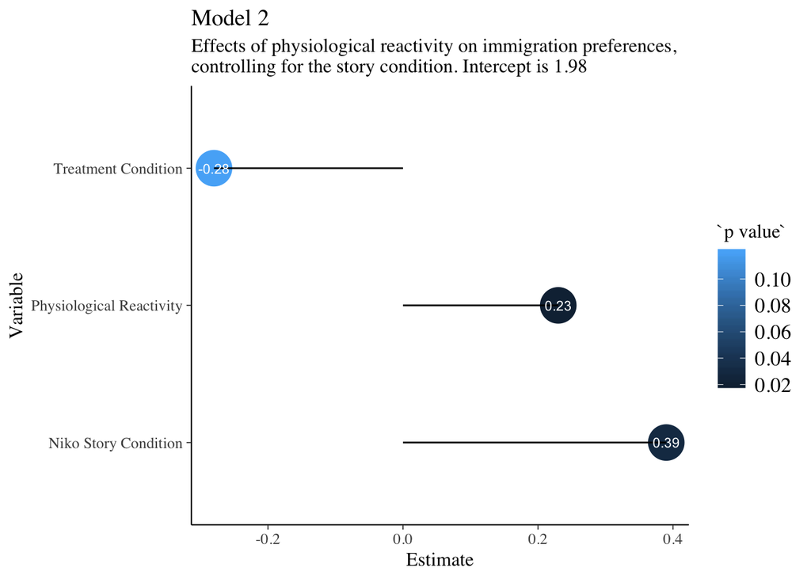

### Figure 3: Causual Mediation Plot

I was able to succesfully recreate all of figure 3 from replication data.

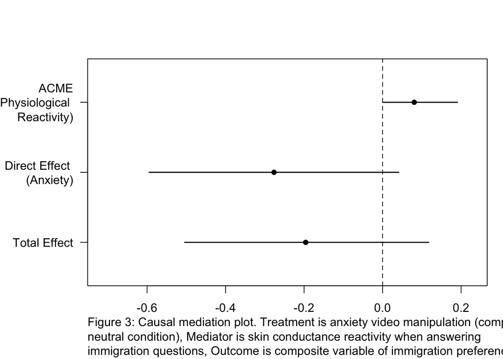

Renshon, Jonathan. 2014a. “Physiological Arousal and Political Beliefs.” *International Society of Political Psychology* xx. Wiley Periodicals, Inc.

———. 2014b. “Replication Data for: Physiological Arousal and Political Beliefs.” Harvard Dataverse. https://doi.org/10.7910/DVN/24318doi/10.7910/DVN/24318.